# Quality Management Plan, Quarterly Report for Quarter 4, 2017 – Red

##### 6mo

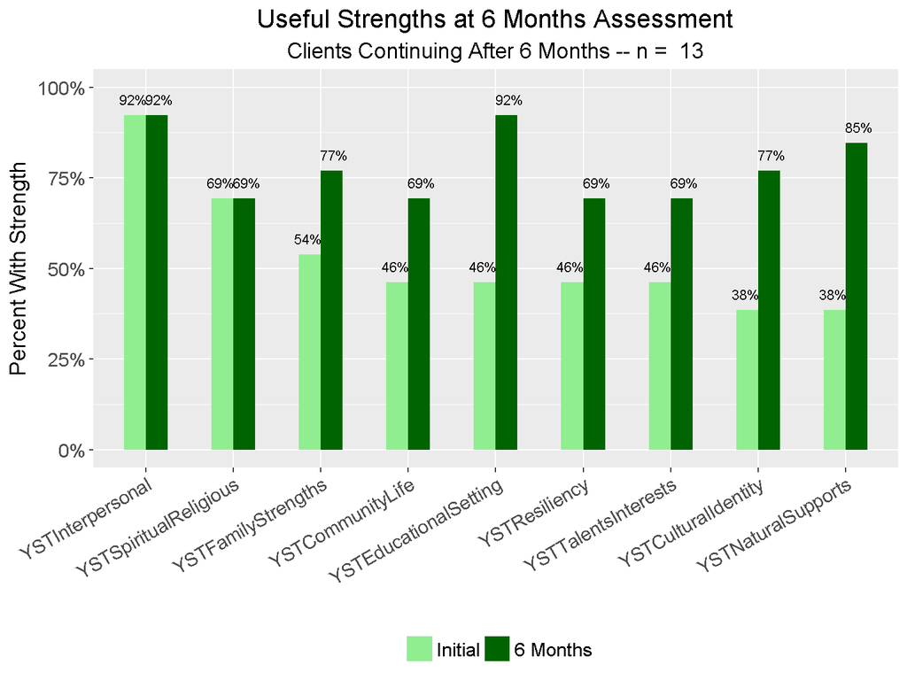

##### 9mo

**A graph cannot be generated, because in the given cohort year and sample, fewer than 10 clients were assessed.**

##### 12mo

**A graph cannot be generated, because in the given cohort year and sample, fewer than 10 clients were assessed.**

##### 15mo

**A graph cannot be generated, because in the given cohort year and sample, fewer than 10 clients were assessed.**

##### 18mo

**A graph cannot be generated, because in the given cohort year and sample, fewer than 10 clients were assessed.**

#### 2017 Cohort

##### Initial

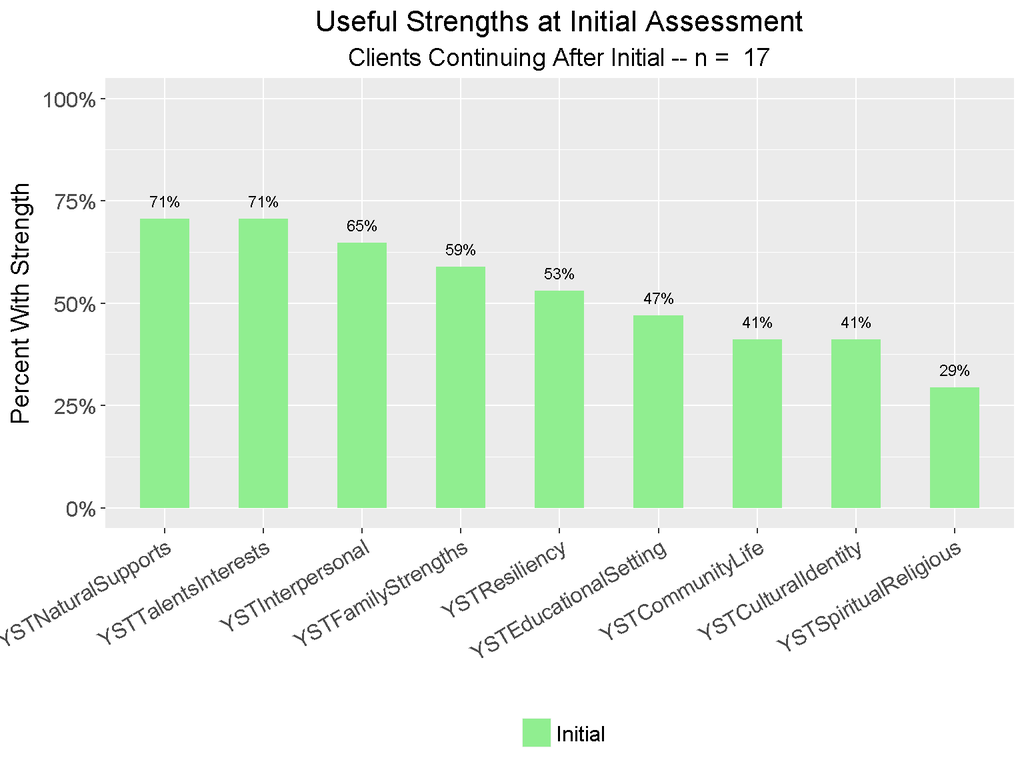

##### 3mo

**A graph cannot be generated, because in the given cohort year and sample, fewer than 10 clients were assessed.**

#### All Cohort

##### Initial

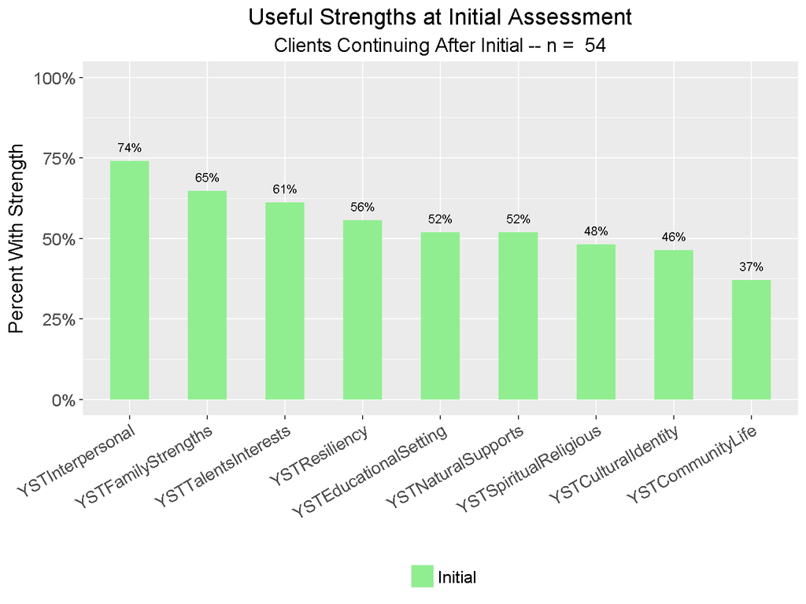

##### 3mo

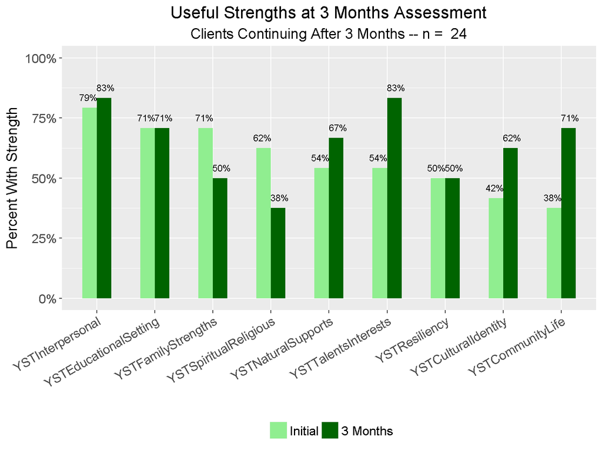

##### 6mo

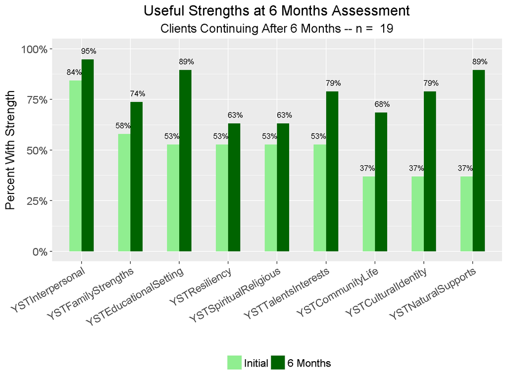

##### 9mo

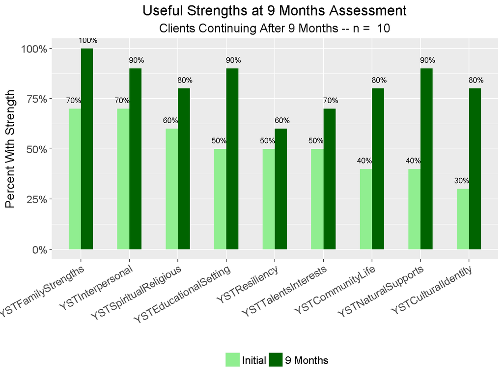

##### 12mo

**A graph cannot be generated, because in the given cohort year and sample, fewer than 10 clients were assessed.**

##### 15mo

**A graph cannot be generated, because in the given cohort year and sample, fewer than 10 clients were assessed.**

##### 18mo

**A graph cannot be generated, because in the given cohort year and sample, fewer than 10 clients were assessed.**

##### 21mo

**A graph cannot be generated, because in the given cohort year and sample, fewer than 10 clients were assessed.**

##### 24mo

**A graph cannot be generated, because in the given cohort year and sample, fewer than 10 clients were assessed.**

##### 27mo

**A graph cannot be generated, because in the given cohort year and sample, fewer than 10 clients were assessed.**

## Intensity of Actionable Needs and Strengths

The following graphs show the average *intensity* of actionable needs and strengths at entry compared to values in future periods, calculated as the averaged sums of all scores of 2 and 3 across items–in the domains of Youth Strengths, Behavioral and Emotional Needs, Life Domain Functioning, and Risk Behaviors.

### Across All Clients

#### 2015 Cohort

##### Initial

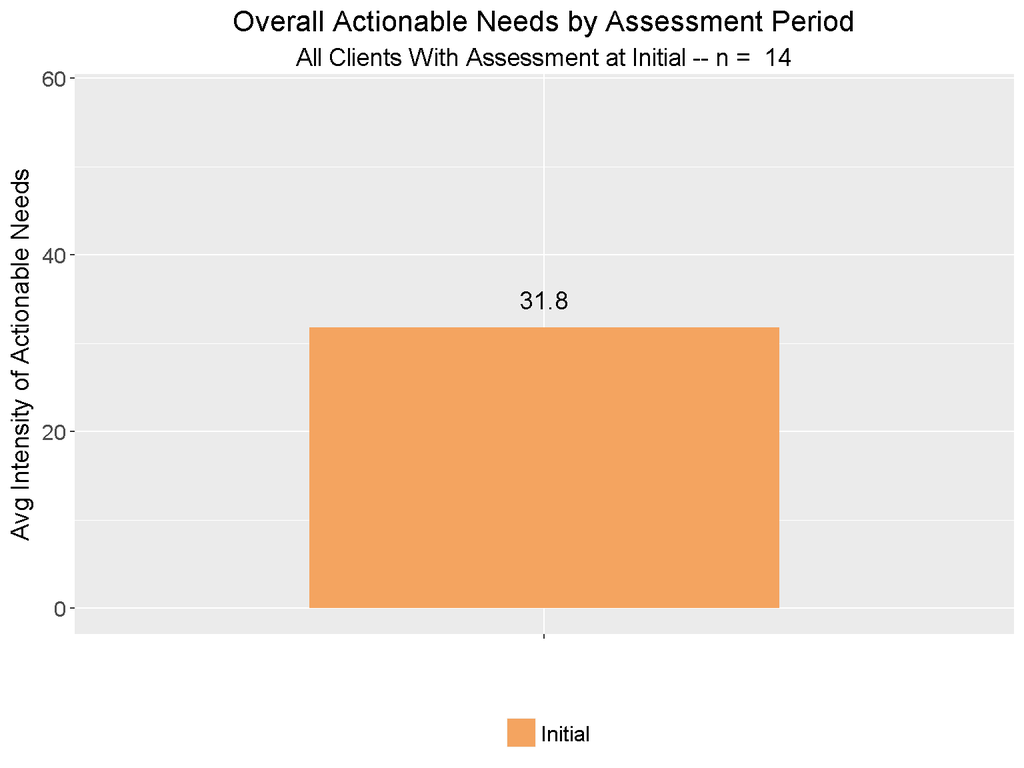

##### 3mo

**A graph cannot be generated, because in the given cohort year and sample, fewer than 10 clients were assessed.**

##### 6mo

**A graph cannot be generated, because in the given cohort year and sample, fewer than 10 clients were assessed.**

##### 9mo

**A graph cannot be generated, because in the given cohort year and sample, fewer than 10 clients were assessed.**

##### 12mo

**A graph cannot be generated, because in the given cohort year and sample, fewer than 10 clients were assessed.**

##### 15mo

**A graph cannot be generated, because in the given cohort year and sample, fewer than 10 clients were assessed.**

##### 18mo

**A graph cannot be generated, because in the given cohort year and sample, fewer than 10 clients were assessed.**

##### 21mo

**A graph cannot be generated, because in the given cohort year and sample, fewer than 10 clients were assessed.**

##### 24mo

**A graph cannot be generated, because in the given cohort year and sample, fewer than 10 clients were assessed.**

##### 27mo

**A graph cannot be generated, because in the given cohort year and sample, fewer than 10 clients were assessed.**

#### 2016 Cohort

##### Initial

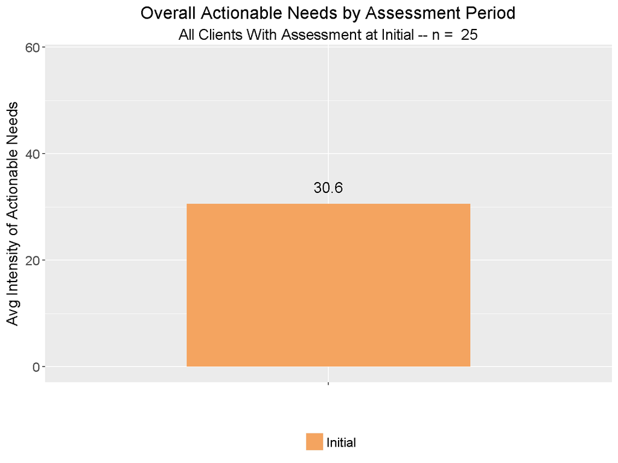

##### 3mo

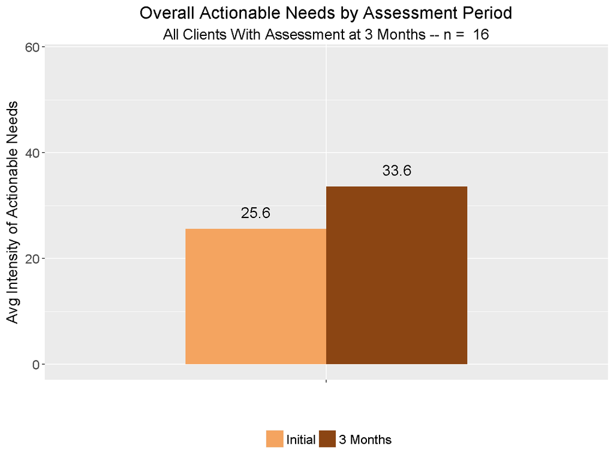

##### 6mo

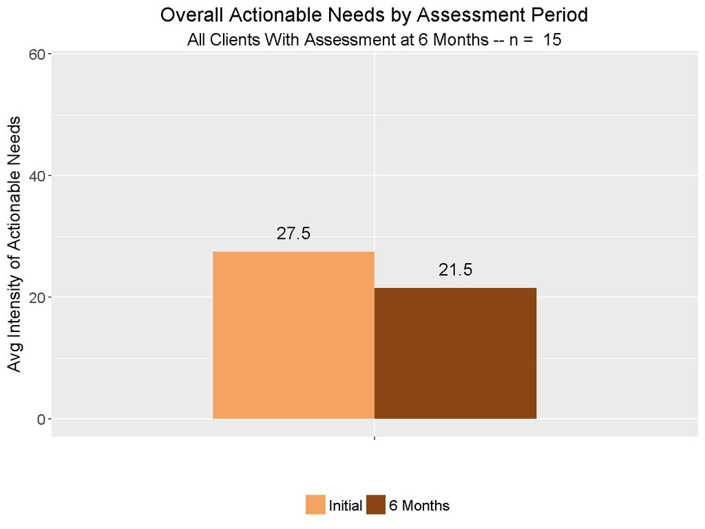

##### 9mo

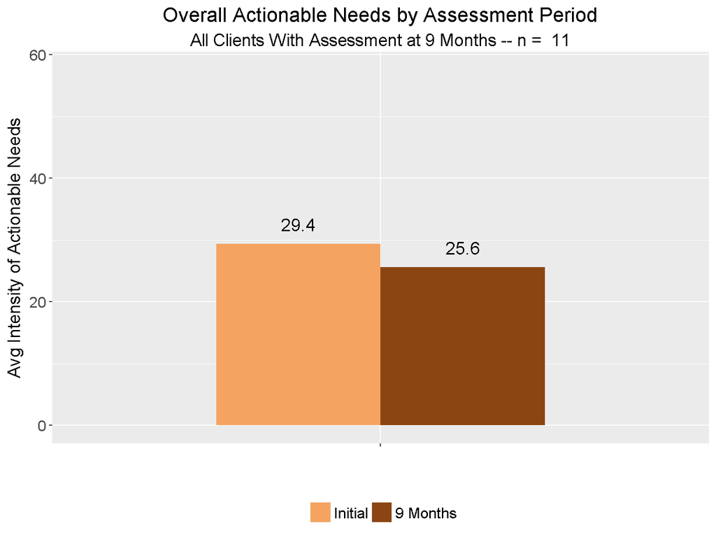

##### 12mo

**A graph cannot be generated, because in the given cohort year and sample, fewer than 10 clients were assessed.**

##### 15mo

**A graph cannot be generated, because in the given cohort year and sample, fewer than 10 clients were assessed.**

##### 18mo

**A graph cannot be generated, because in the given cohort year and sample, fewer than 10 clients were assessed.**

#### 2017 Cohort

##### Initial

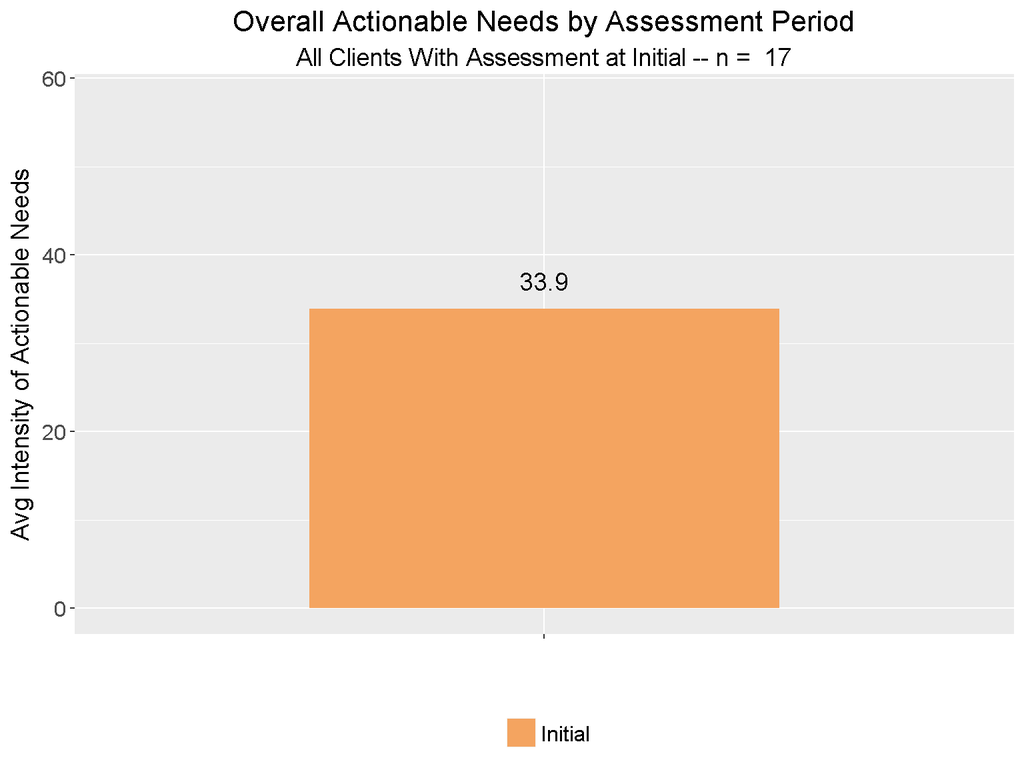

##### 3mo

**A graph cannot be generated, because in the given cohort year and sample, fewer than 10 clients were assessed.**

#### All Cohort

##### Initial

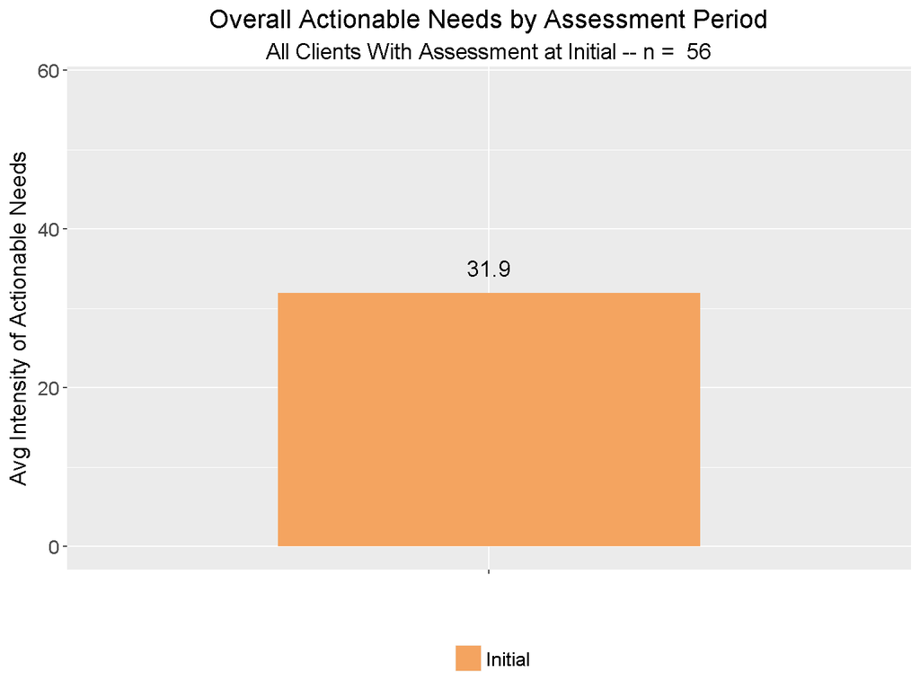

##### 3mo

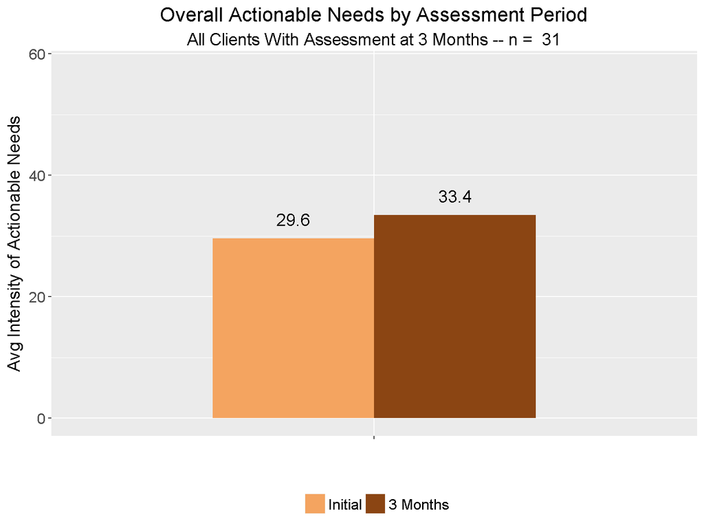

##### 6mo

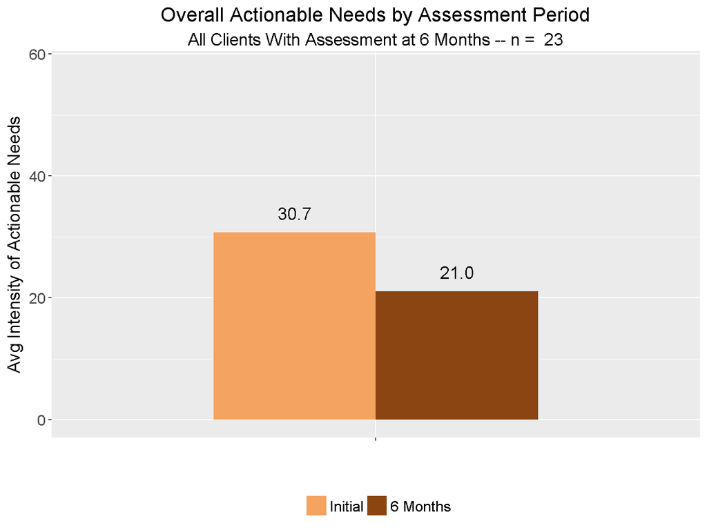

##### 9mo

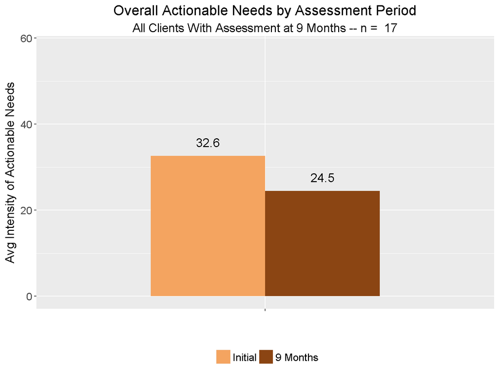

##### 12mo

**A graph cannot be generated, because in the given cohort year and sample, fewer than 10 clients were assessed.**

##### 15mo

**A graph cannot be generated, because in the given cohort year and sample, fewer than 10 clients were assessed.**

##### 18mo

**A graph cannot be generated, because in the given cohort year and sample, fewer than 10 clients were assessed.**

##### 21mo

**A graph cannot be generated, because in the given cohort year and sample, fewer than 10 clients were assessed.**

##### 24mo

**A graph cannot be generated, because in the given cohort year and sample, fewer than 10 clients were assessed.**

##### 27mo

**A graph cannot be generated, because in the given cohort year and sample, fewer than 10 clients were assessed.**

### Discharged After Reassessment

The figures below focus on only clients discharged from care as of the indicated reassessment.

#### 2015 Cohort

##### 3mo

**A graph cannot be generated, because in the given cohort year and sample, fewer than 10 clients were assessed.**

##### 6mo

**A graph cannot be generated, because in the given cohort year and sample, fewer than 10 clients were assessed.**

##### 9mo

**A graph cannot be generated, because in the given cohort year and sample, fewer than 10 clients were assessed.**

##### 18mo

**A graph cannot be generated, because in the given cohort year and sample, fewer than 10 clients were assessed.**

#### 2016 Cohort

##### Initial

**A graph cannot be generated, because in the given cohort year and sample, fewer than 10 clients were assessed.**

##### 3mo

**A graph cannot be generated, because in the given cohort year and sample, fewer than 10 clients were assessed.**

##### 6mo

**A graph cannot be generated, because in the given cohort year and sample, fewer than 10 clients were assessed.**

##### 9mo

**A graph cannot be generated, because in the given cohort year and sample, fewer than 10 clients were assessed.**

##### 12mo

**A graph cannot be generated, because in the given cohort year and sample, fewer than 10 clients were assessed.**

#### 2017 Cohort

##### 3mo

**A graph cannot be generated, because in the given cohort year and sample, fewer than 10 clients were assessed.**

#### All Cohort

##### Initial

**A graph cannot be generated, because in the given cohort year and sample, fewer than 10 clients were assessed.**

##### 3mo

**A graph cannot be generated, because in the given cohort year and sample, fewer than 10 clients were assessed.**

##### 6mo

**A graph cannot be generated, because in the given cohort year and sample, fewer than 10 clients were assessed.**

##### 9mo

**A graph cannot be generated, because in the given cohort year and sample, fewer than 10 clients were assessed.**

##### 12mo

**A graph cannot be generated, because in the given cohort year and sample, fewer than 10 clients were assessed.**

##### 18mo

**A graph cannot be generated, because in the given cohort year and sample, fewer than 10 clients were assessed.**

### Continuing After Reassessment

The figures below focus on only clients continuing in care as of the indicated reassessment.

#### 2015 Cohort

##### Initial

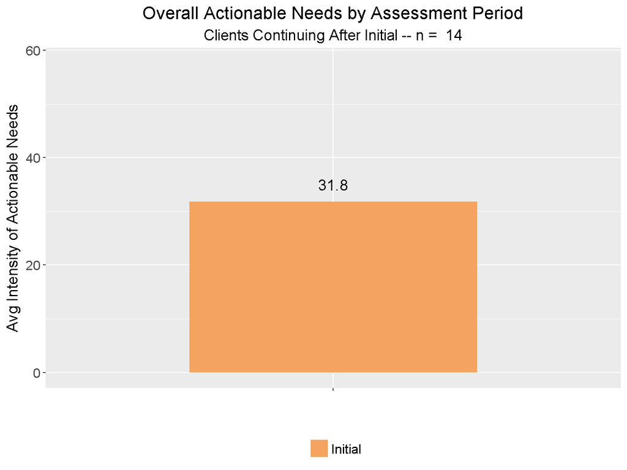

##### 3mo

**A graph cannot be generated, because in the given cohort year and sample, fewer than 10 clients were assessed.**

##### 6mo

**A graph cannot be generated, because in the given cohort year and sample, fewer than 10 clients were assessed.**

##### 9mo

**A graph cannot be generated, because in the given cohort year and sample, fewer than 10 clients were assessed.**

##### 12mo

**A graph cannot be generated, because in the given cohort year and sample, fewer than 10 clients were assessed.**

##### 15mo

**A graph cannot be generated, because in the given cohort year and sample, fewer than 10 clients were assessed.**

##### 18mo

**A graph cannot be generated, because in the given cohort year and sample, fewer than 10 clients were assessed.**

##### 21mo

**A graph cannot be generated, because in the given cohort year and sample, fewer than 10 clients were assessed.**

##### 24mo

**A graph cannot be generated, because in the given cohort year and sample, fewer than 10 clients were assessed.**

##### 27mo

**A graph cannot be generated, because in the given cohort year and sample, fewer than 10 clients were assessed.**

#### 2016 Cohort

##### Initial

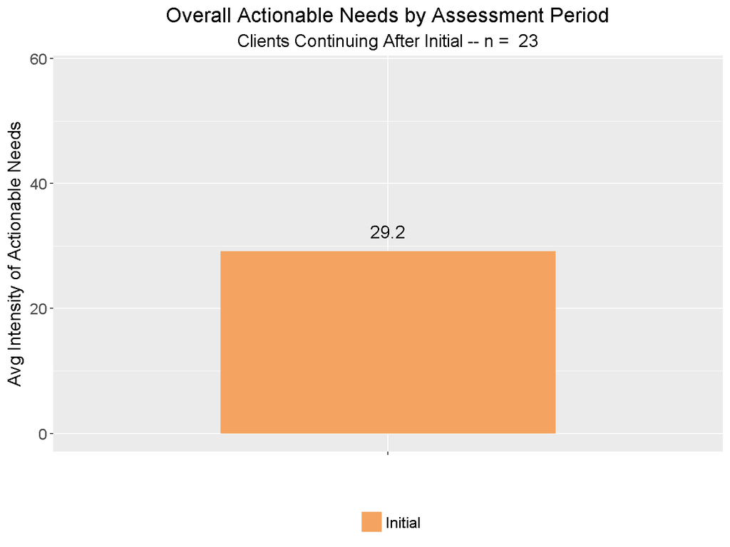

##### 3mo

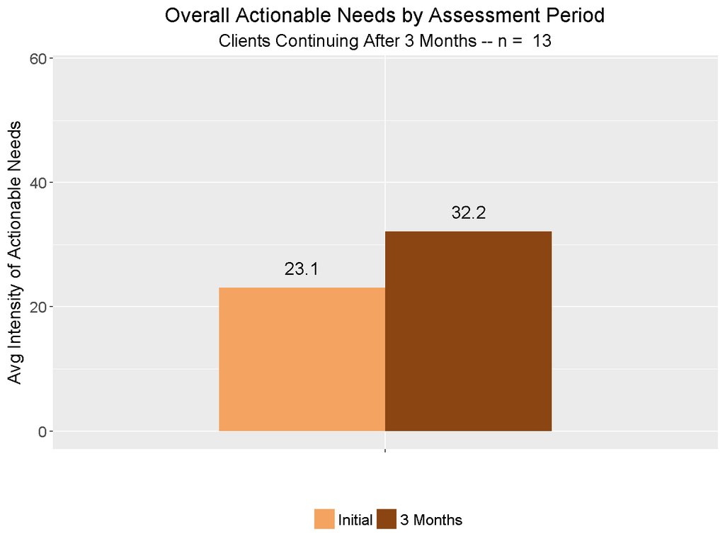

##### 6mo

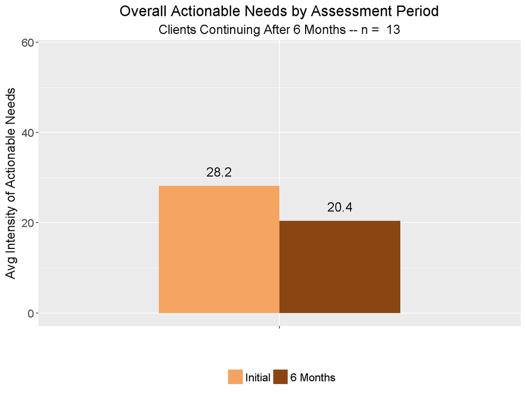

##### 9mo

**A graph cannot be generated, because in the given cohort year and sample, fewer than 10 clients were assessed.**

##### 12mo

**A graph cannot be generated, because in the given cohort year and sample, fewer than 10 clients were assessed.**

##### 15mo

**A graph cannot be generated, because in the given cohort year and sample, fewer than 10 clients were assessed.**

##### 18mo

**A graph cannot be generated, because in the given cohort year and sample, fewer than 10 clients were assessed.**

#### 2017 Cohort

##### Initial

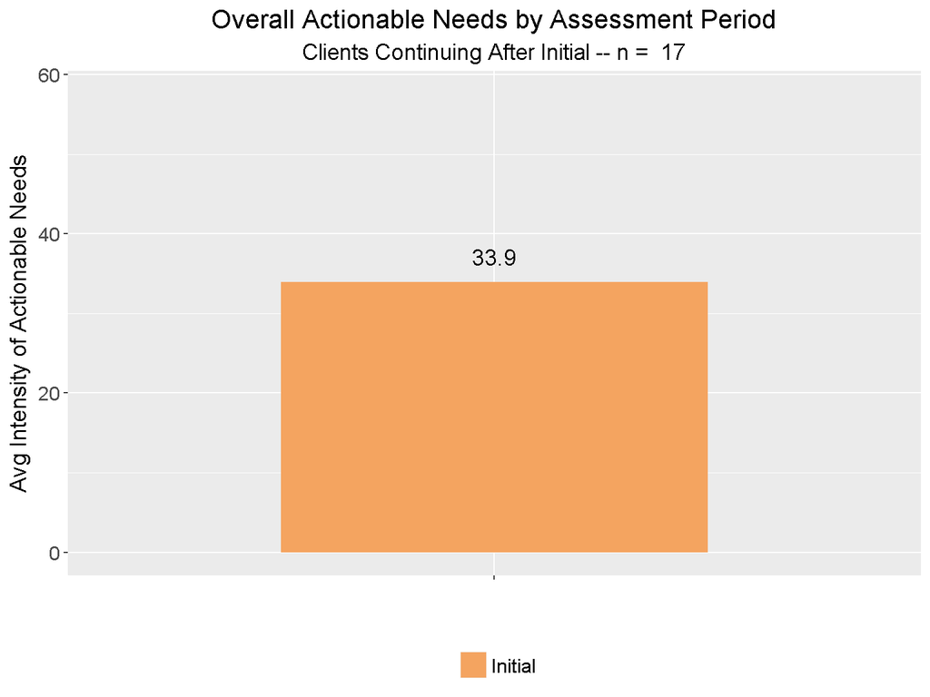

##### 3mo

**A graph cannot be generated, because in the given cohort year and sample, fewer than 10 clients were assessed.**

#### All Cohort

##### Initial

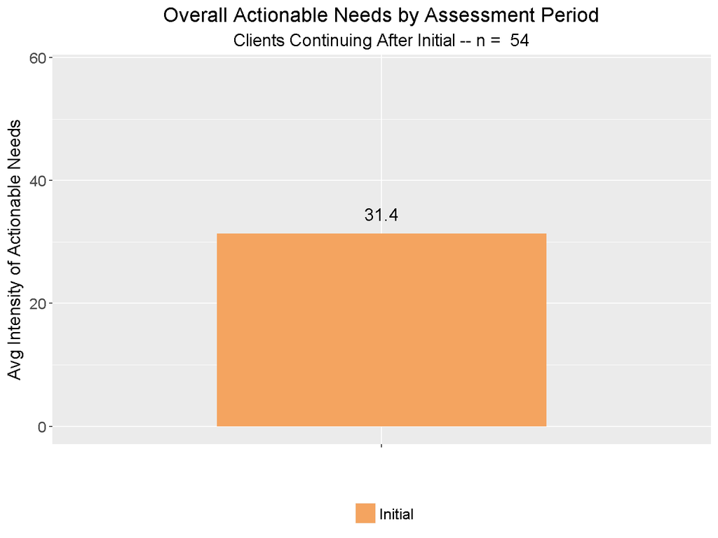

##### 3mo

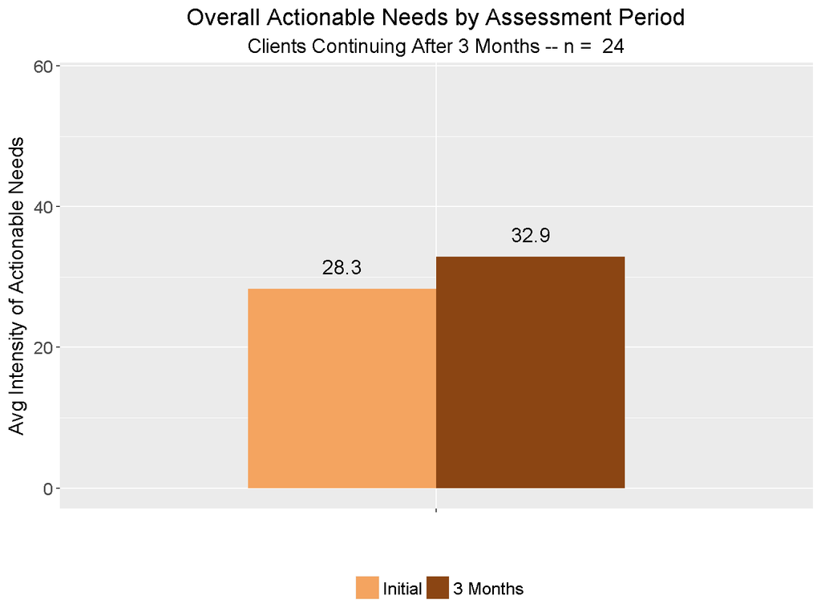

##### 6mo

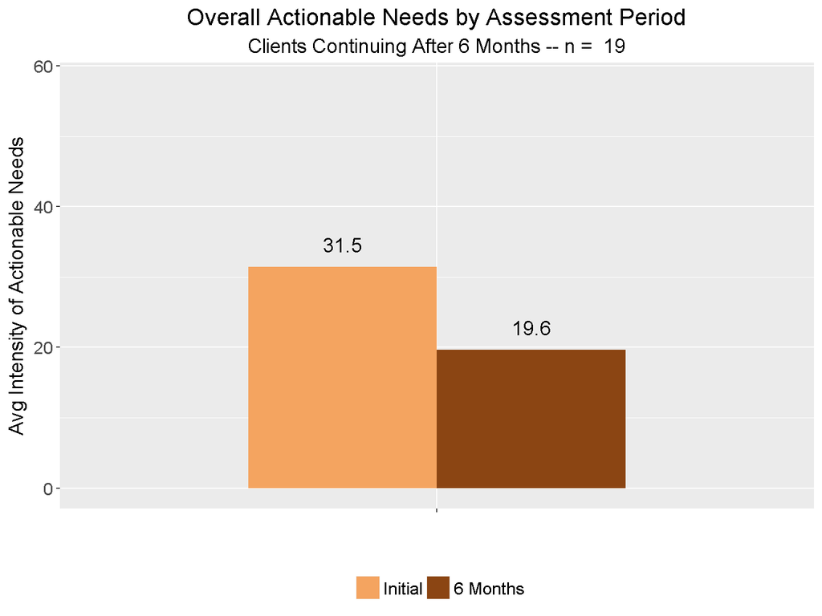

##### 9mo

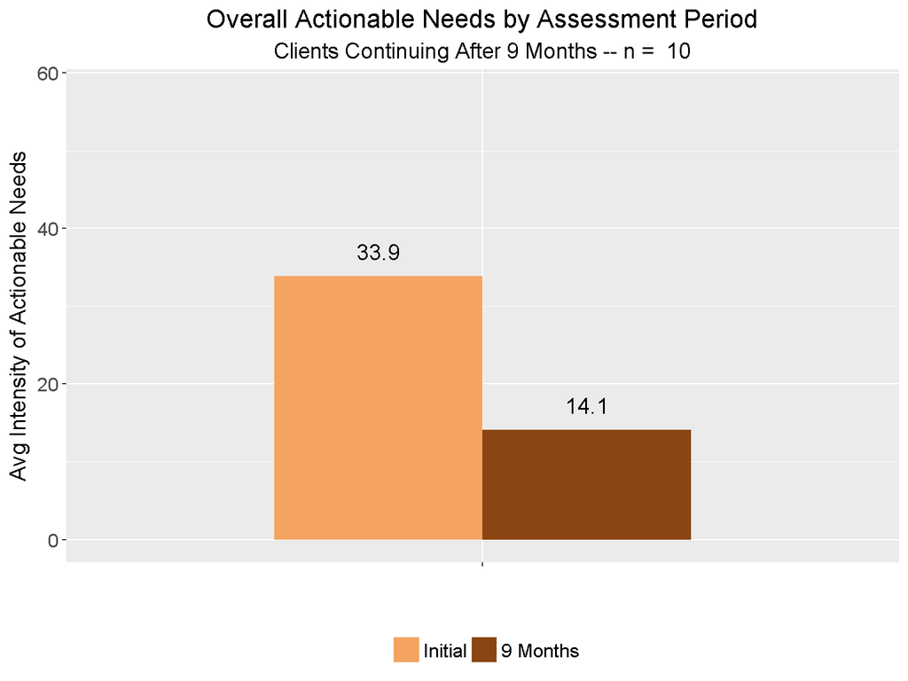

##### 12mo

**A graph cannot be generated, because in the given cohort year and sample, fewer than 10 clients were assessed.**

##### 15mo

**A graph cannot be generated, because in the given cohort year and sample, fewer than 10 clients were assessed.**

##### 18mo

**A graph cannot be generated, because in the given cohort year and sample, fewer than 10 clients were assessed.**

##### 21mo

**A graph cannot be generated, because in the given cohort year and sample, fewer than 10 clients were assessed.**

##### 24mo

**A graph cannot be generated, because in the given cohort year and sample, fewer than 10 clients were assessed.**

##### 27mo

**A graph cannot be generated, because in the given cohort year and sample, fewer than 10 clients were assessed.**

## Number of Actionable Needs

These graphs report an average *number* of all actionable needs at entry–i.e. the number of items which are scored with either a ‘2’ or ‘3’ on the CANS–in the domains of Behavioral and Emotional Needs, Life Domain Functioning, and Risk Behaviors. These graphs show scores at Initial assessment and, if applicable, the average number of actionable needs at a later reassessment period for the subset of clients assess at that time.

The actionable needs at entry represents the average number of all strengths and needs items which are scored with either a ‘2’ or ‘3’.

### Comparison Across Time

#### By Month

Note that some points in the graph below are suppressed because the overall number of clients assessed in that given time period falls below 10, which is the cutoff used to ensure client privacy.

[figure not shown]

#### By Quarter

Note that some points in the graph below are suppressed because the overall number of clients assessed in that given time period falls below 10, which is the cutoff used to ensure client privacy.

[figure not shown]

#### By Month, Contrasting Year

Note that some points in the graph below are suppressed because the overall number of clients assessed in that given time period falls below 10, which is the cutoff used to ensure client privacy.

[figure not shown]

#### By Quarter, Contrasting Year

Note that some points in the graph below are suppressed because the overall number of clients assessed in that given time period falls below 10, which is the cutoff used to ensure client privacy.

[figure not shown]

### Comparisons Across Assessments, by Cohort

These graphs also report an average *number* of all actionable needs at entry–i.e. the number of items which are scored with either a ‘2’ or ‘3’ on the CANS–in the domains of Behavioral and Emotional Needs, Life Domain Functioning, and Risk Behaviors. These graphs contrast cohorts between initial and reassessments, where cohorts are grouped by those who were discharged or continuing in care at the given assessment and the year of the client’s episode start date.

#### Across All Clients

##### 2015 Cohort

###### Initial

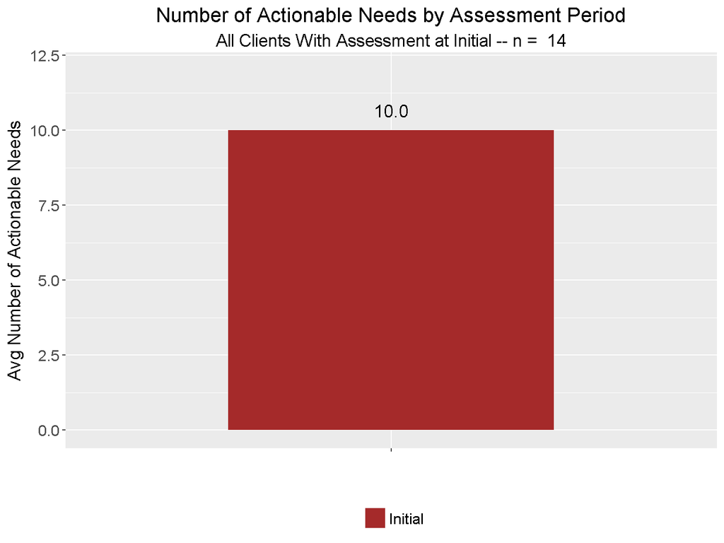

###### 3mo

**A graph cannot be generated, because in the given cohort year and sample, fewer than 10 clients were assessed.**

###### 6mo

**A graph cannot be generated, because in the given cohort year and sample, fewer than 10 clients were assessed.**

###### 9mo

**A graph cannot be generated, because in the given cohort year and sample, fewer than 10 clients were assessed.**

###### 12mo

**A graph cannot be generated, because in the given cohort year and sample, fewer than 10 clients were assessed.**

###### 15mo

**A graph cannot be generated, because in the given cohort year and sample, fewer than 10 clients were assessed.**

###### 18mo

**A graph cannot be generated, because in the given cohort year and sample, fewer than 10 clients were assessed.**

###### 21mo

**A graph cannot be generated, because in the given cohort year and sample, fewer than 10 clients were assessed.**

###### 24mo

**A graph cannot be generated, because in the given cohort year and sample, fewer than 10 clients were assessed.**

###### 27mo

**A graph cannot be generated, because in the given cohort year and sample, fewer than 10 clients were assessed.**

##### 2016 Cohort

###### Initial

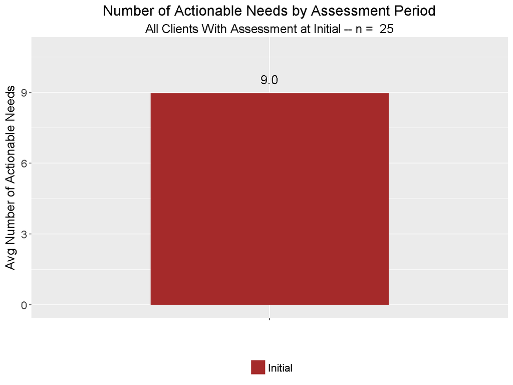

###### 3mo

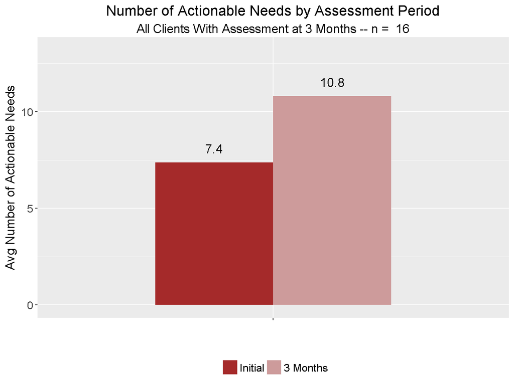

###### 6mo

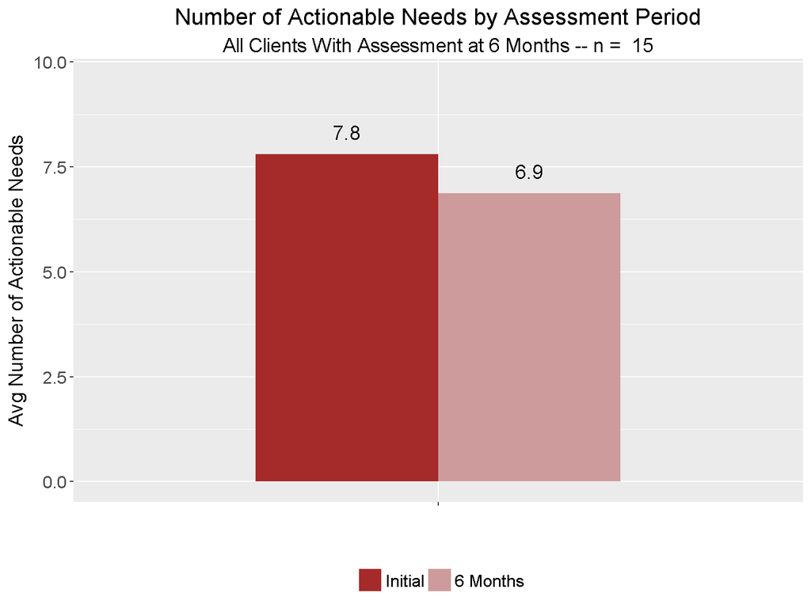

###### 9mo

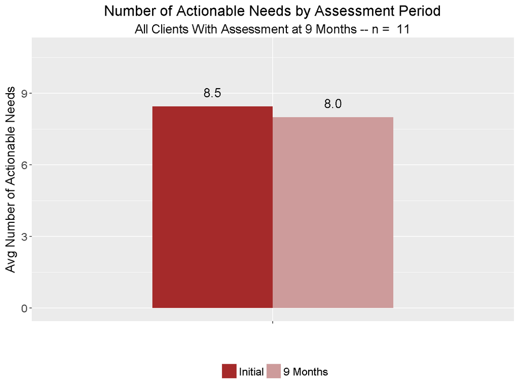

###### 12mo

**A graph cannot be generated, because in the given cohort year and sample, fewer than 10 clients were assessed.**

###### 15mo

**A graph cannot be generated, because in the given cohort year and sample, fewer than 10 clients were assessed.**

###### 18mo

**A graph cannot be generated, because in the given cohort year and sample, fewer than 10 clients were assessed.**

##### 2017 Cohort

###### Initial

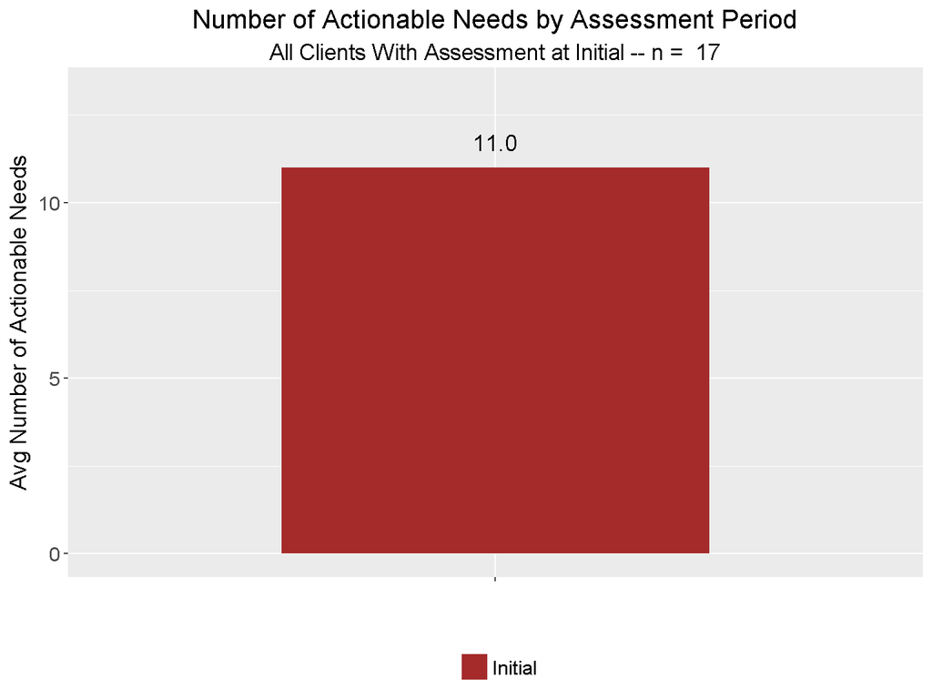

###### 3mo

**A graph cannot be generated, because in the given cohort year and sample, fewer than 10 clients were assessed.**

##### All Cohort

###### Initial

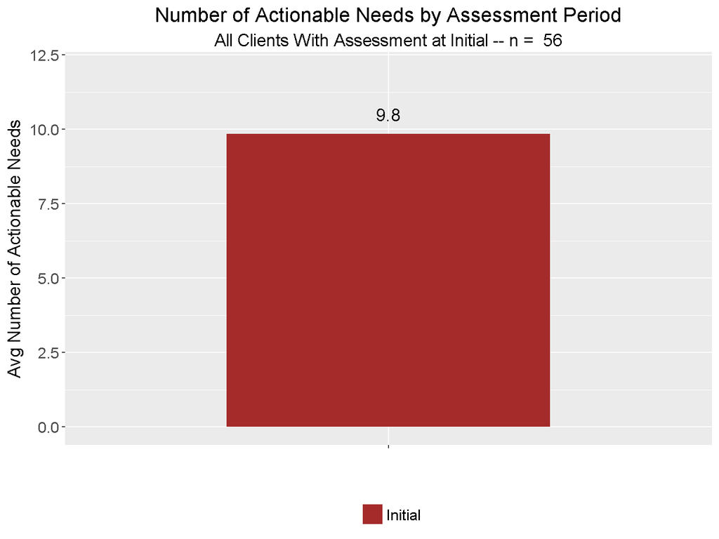

###### 3mo

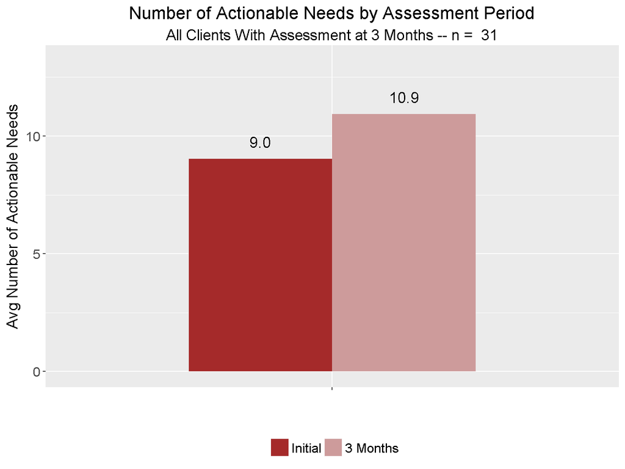

###### 6mo

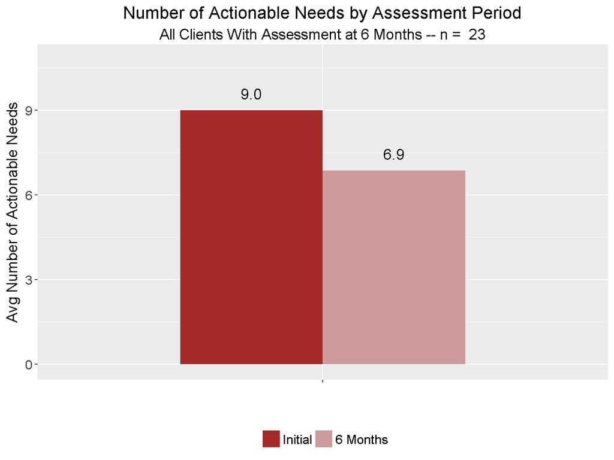

###### 9mo

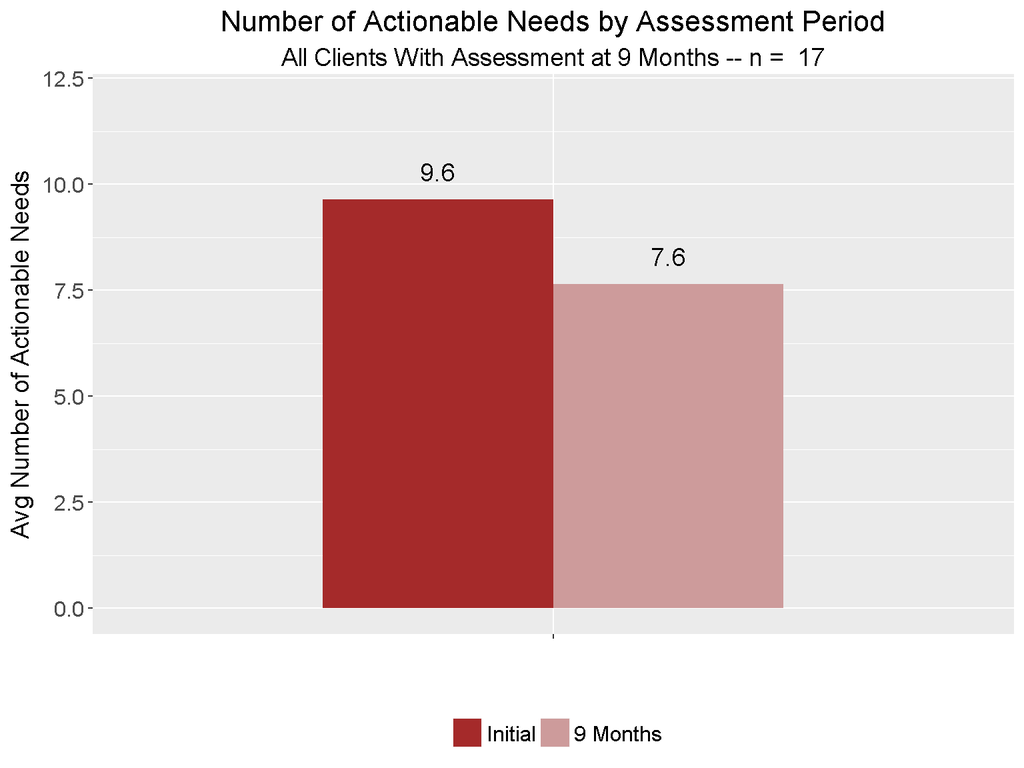

###### 12mo

**A graph cannot be generated, because in the given cohort year and sample, fewer than 10 clients were assessed.**

###### 15mo

**A graph cannot be generated, because in the given cohort year and sample, fewer than 10 clients were assessed.**

###### 18mo

**A graph cannot be generated, because in the given cohort year and sample, fewer than 10 clients were assessed.**

###### 21mo

**A graph cannot be generated, because in the given cohort year and sample, fewer than 10 clients were assessed.**

###### 24mo

**A graph cannot be generated, because in the given cohort year and sample, fewer than 10 clients were assessed.**

###### 27mo

**A graph cannot be generated, because in the given cohort year and sample, fewer than 10 clients were assessed.**

#### Discharged After Reassessment

The figures below focus on only clients discharged from care as of the indicated reassessment.

##### 2015 Cohort

###### 3mo

**A graph cannot be generated, because in the given cohort year and sample, fewer than 10 clients were assessed.**

###### 6mo

**A graph cannot be generated, because in the given cohort year and sample, fewer than 10 clients were assessed.**

###### 9mo

**A graph cannot be generated, because in the given cohort year and sample, fewer than 10 clients were assessed.**

###### 18mo

**A graph cannot be generated, because in the given cohort year and sample, fewer than 10 clients were assessed.**

##### 2016 Cohort

###### Initial

**A graph cannot be generated, because in the given cohort year and sample, fewer than 10 clients were assessed.**

###### 3mo

**A graph cannot be generated, because in the given cohort year and sample, fewer than 10 clients were assessed.**

###### 6mo

**A graph cannot be generated, because in the given cohort year and sample, fewer than 10 clients were assessed.**

###### 9mo

**A graph cannot be generated, because in the given cohort year and sample, fewer than 10 clients were assessed.**

###### 12mo

**A graph cannot be generated, because in the given cohort year and sample, fewer than 10 clients were assessed.**

##### 2017 Cohort

###### 3mo

**A graph cannot be generated, because in the given cohort year and sample, fewer than 10 clients were assessed.**

##### All Cohort

###### Initial

**A graph cannot be generated, because in the given cohort year and sample, fewer than 10 clients were assessed.**

###### 3mo

**A graph cannot be generated, because in the given cohort year and sample, fewer than 10 clients were assessed.**

###### 6mo

**A graph cannot be generated, because in the given cohort year and sample, fewer than 10 clients were assessed.**

###### 9mo

**A graph cannot be generated, because in the given cohort year and sample, fewer than 10 clients were assessed.**

###### 12mo

**A graph cannot be generated, because in the given cohort year and sample, fewer than 10 clients were assessed.**

###### 18mo

**A graph cannot be generated, because in the given cohort year and sample, fewer than 10 clients were assessed.**

#### Continuing After Reassessment

The figures below focus on only clients continuing in care as of the indicated reassessment.

##### 2015 Cohort

###### Initial

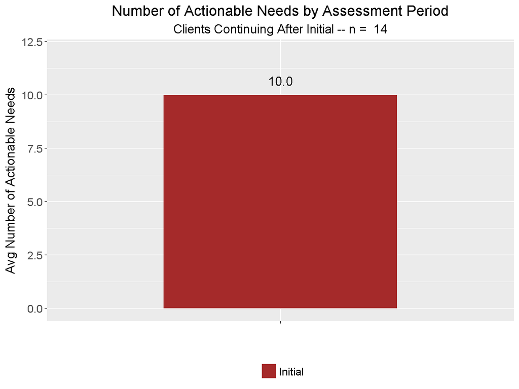

###### 3mo

**A graph cannot be generated, because in the given cohort year and sample, fewer than 10 clients were assessed.**

###### 6mo

**A graph cannot be generated, because in the given cohort year and sample, fewer than 10 clients were assessed.**

###### 9mo

**A graph cannot be generated, because in the given cohort year and sample, fewer than 10 clients were assessed.**

###### 12mo

**A graph cannot be generated, because in the given cohort year and sample, fewer than 10 clients were assessed.**

###### 15mo

**A graph cannot be generated, because in the given cohort year and sample, fewer than 10 clients were assessed.**

###### 18mo

**A graph cannot be generated, because in the given cohort year and sample, fewer than 10 clients were assessed.**

###### 21mo

**A graph cannot be generated, because in the given cohort year and sample, fewer than 10 clients were assessed.**

###### 24mo

**A graph cannot be generated, because in the given cohort year and sample, fewer than 10 clients were assessed.**

###### 27mo

**A graph cannot be generated, because in the given cohort year and sample, fewer than 10 clients were assessed.**

##### 2016 Cohort

###### Initial

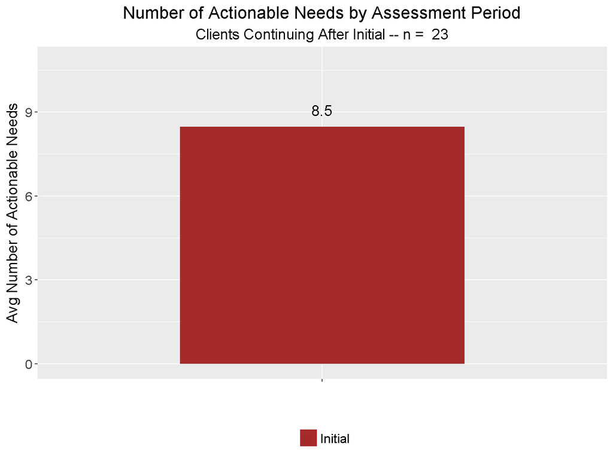

###### 3mo

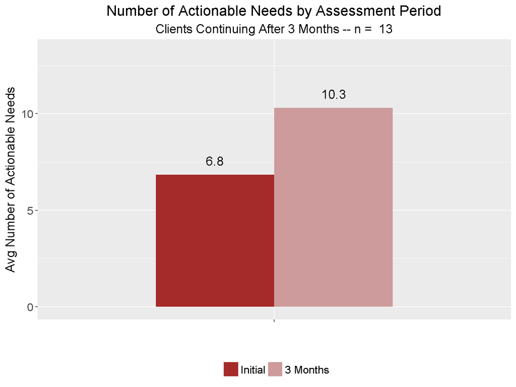

###### 6mo

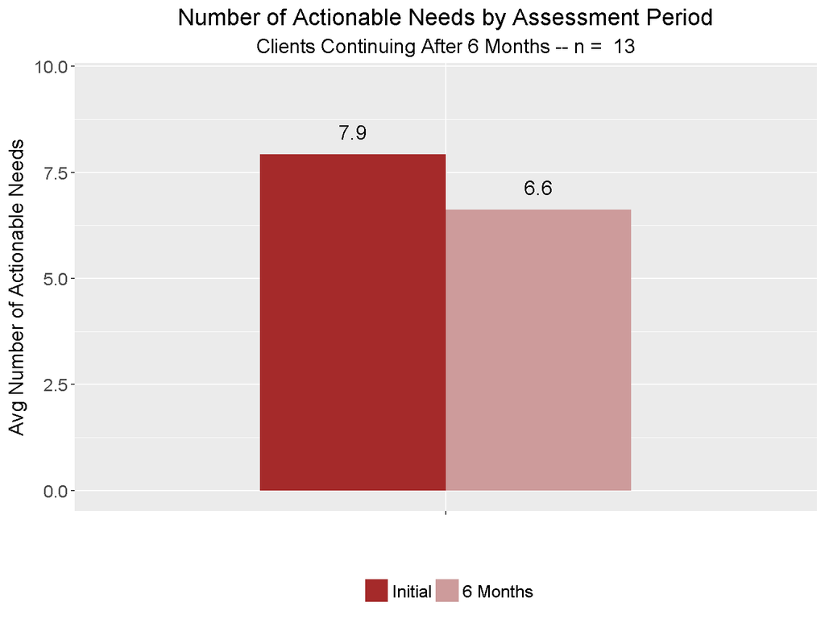

###### 9mo

**A graph cannot be generated, because in the given cohort year and sample, fewer than 10 clients were assessed.**

###### 12mo

**A graph cannot be generated, because in the given cohort year and sample, fewer than 10 clients were assessed.**

###### 15mo

**A graph cannot be generated, because in the given cohort year and sample, fewer than 10 clients were assessed.**

###### 18mo

**A graph cannot be generated, because in the given cohort year and sample, fewer than 10 clients were assessed.**

##### 2017 Cohort

###### Initial

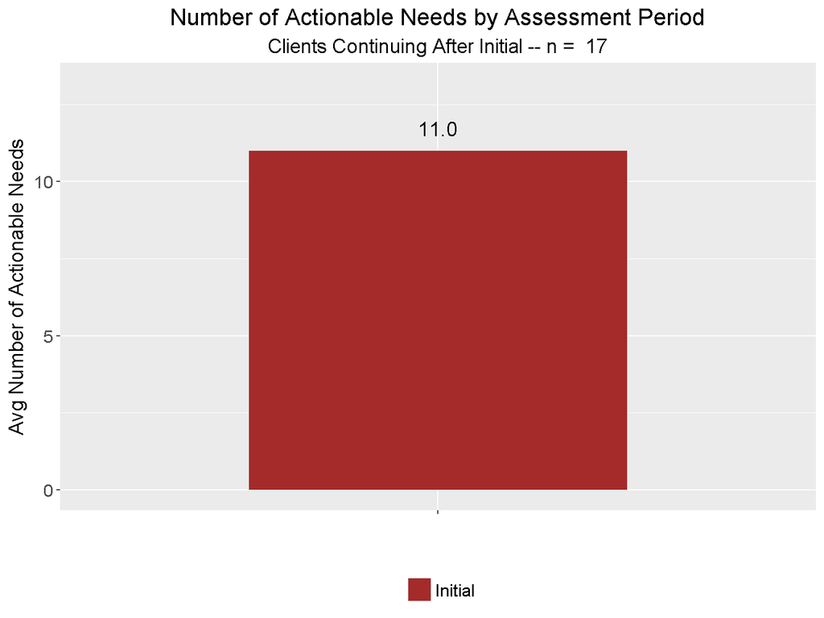

###### 3mo

**A graph cannot be generated, because in the given cohort year and sample, fewer than 10 clients were assessed.**

##### All Cohort

###### Initial

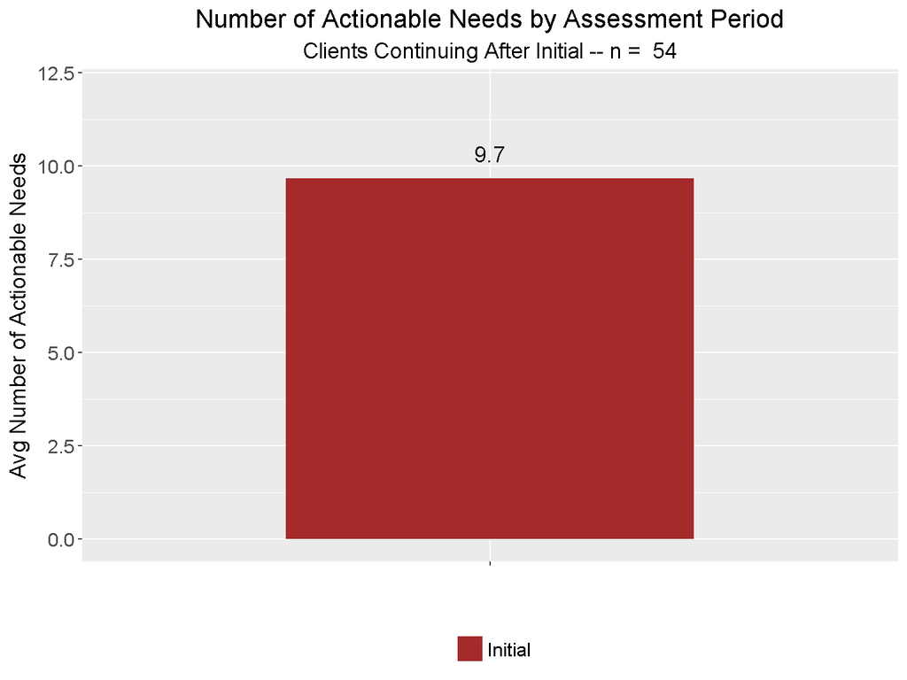

###### 3mo

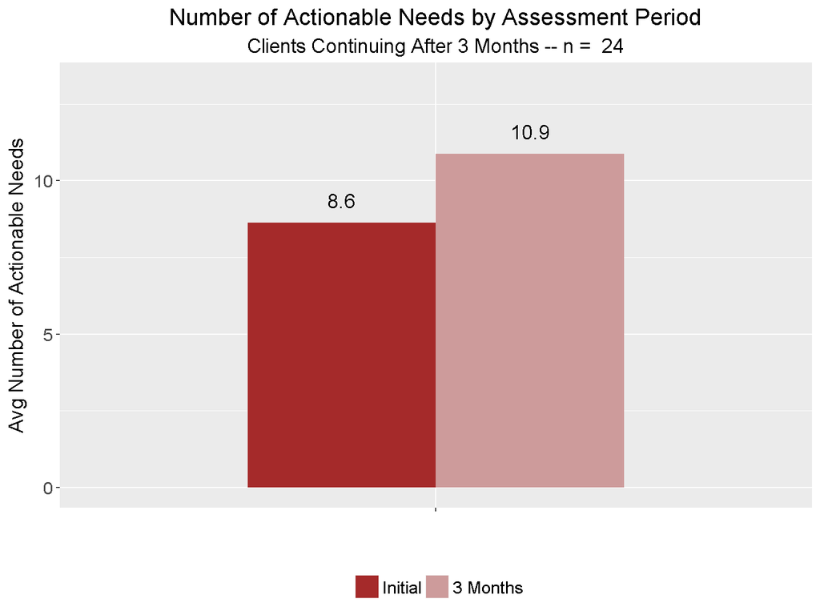

###### 6mo

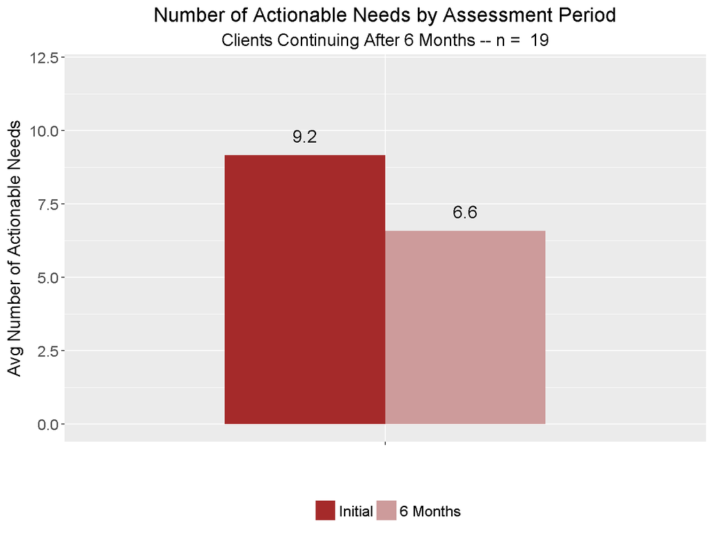

###### 9mo

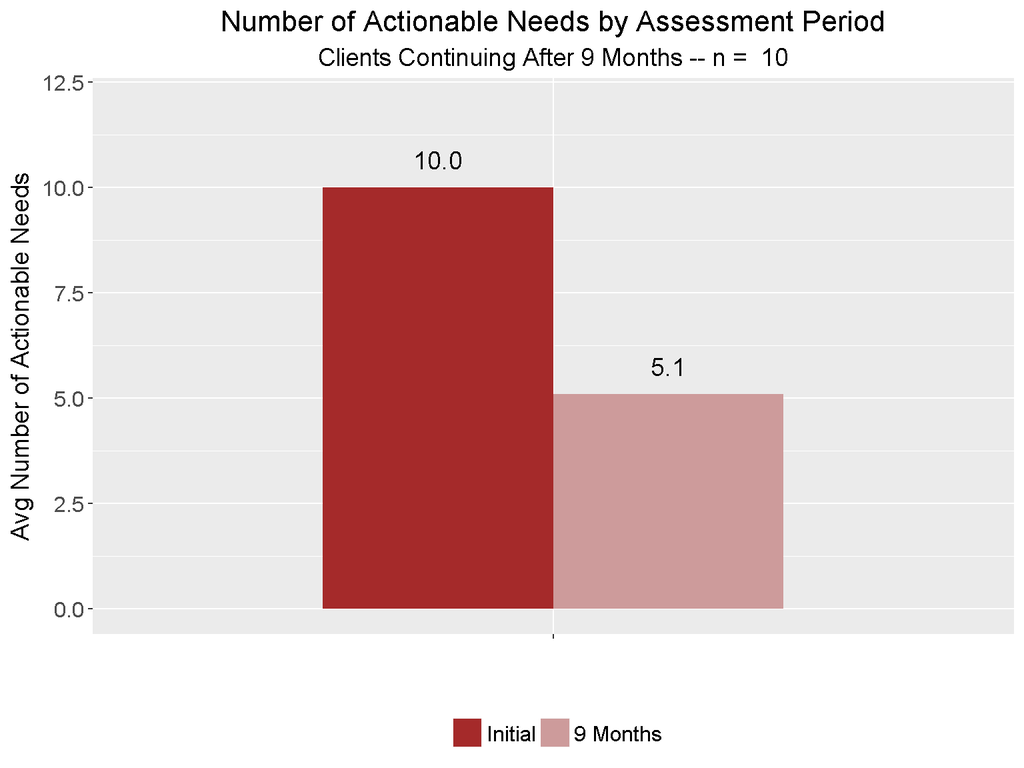

###### 12mo

**A graph cannot be generated, because in the given cohort year and sample, fewer than 10 clients were assessed.**

###### 15mo

**A graph cannot be generated, because in the given cohort year and sample, fewer than 10 clients were assessed.**

###### 18mo

**A graph cannot be generated, because in the given cohort year and sample, fewer than 10 clients were assessed.**

###### 21mo

**A graph cannot be generated, because in the given cohort year and sample, fewer than 10 clients were assessed.**

###### 24mo

**A graph cannot be generated, because in the given cohort year and sample, fewer than 10 clients were assessed.**

###### 27mo

**A graph cannot be generated, because in the given cohort year and sample, fewer than 10 clients were assessed.**